# Time Series Final Project

Mariam Adeyemo

2023-05-25

### Energy Generation Time Series Analysis for all Sectors in Illinois State from January 2001 - March 2022

#### Load the dataset

```r
Datapath <- getwd()

#load the dataset
energy_df <- read.csv(file.path(Datapath, "electricity_data.csv"))

#view the dataset
#head(energy_df, 5)
```

#### Extract the Illinois dataset

```r
library(dplyr)
#get the Illinois dataset
illinois_df <- select(energy_df, X, Illinois...all.sectors)

head(illinois_df, 5)
```

```
##            X Illinois...all.sectors
## 1 2001-01-01                  16039
## 2 2001-02-01                  13914
## 3 2001-03-01                  14882
## 4 2001-04-01                  13320
## 5 2001-05-01                  14605
```

### EDA

```r
#check the data type
str(illinois_df)
```

```
## 'data.frame':    255 obs. of  2 variables:
##  $ X                     : chr  "2001-01-01" "2001-02-01" "2001-03-01" "2001-04-01" ...
##  $ Illinois...all.sectors: int  16039 13914 14882 13320 14605 15411 17030 16995 14281 13842 ...
```

```r
#check for missing values
colSums(is.na(illinois_df))
```

```
##                      X Illinois...all.sectors
##                      0                      0
```

There are no missing data

```r
#convert the date column into a date type
illinois_df$X <- as.Date(illinois_df$X)

# Change the name of a date column
colnames(illinois_df)[1] <- "Date"

sapply(illinois_df, class)
```

```
##                   Date Illinois...all.sectors
##                 "Date"              "integer"
```

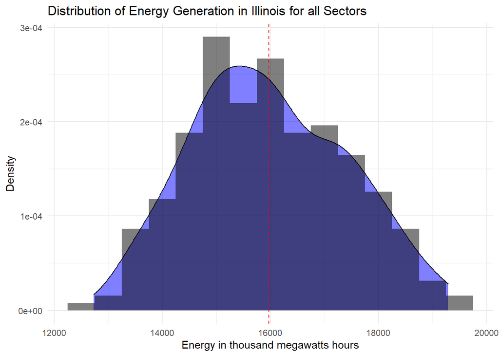

```r
library(ggplot2)

# Plot the density and histogram
ggplot(illinois_df, aes(x = Illinois...all.sectors)) +
  geom_density(fill = "blue", alpha = 0.5) +  # Density plot
  geom_histogram(aes(y = ..density..), fill = "black", alpha = 0.5, binwidth = 500) +  # Histogram
  geom_vline(aes(xintercept = mean(Illinois...all.sectors)), color = "red", linetype = "dashed") +  # Mean line
  labs(x = "Energy in thousand megawatts hours", y = "Density", title = "Distribution of Energy Generation in Illinois for all Sectors") +
  theme_minimal()
```

```r
library(moments)

# Calculate summary statistics
mean_value <- mean(illinois_df$Illinois...all.sectors)
median_value <- median(illinois_df$Illinois...all.sectors)
std_dev <- sd(illinois_df$Illinois...all.sectors)
skewness <- moments::skewness(illinois_df$Illinois...all.sectors)
kurtosis <- moments::kurtosis(illinois_df$Illinois...all.sectors)

# Print the summary statistics
cat("Summary Statistics of the Energy Generation in Illinois for all Sectors:")
```

```
## Summary Statistics of the Energy Generation in Illinois for all Sectors:
```

```r
cat("\nMean:", mean_value)
```

```
##
## Mean: 15971.55
```

```r
cat("\nMedian:", median_value)
```

```
##
## Median: 15860
```

```r
cat("\nStandard Deviation:", std_dev)
```

```
##
## Standard Deviation: 1425.369
```

```r
cat("\nSkewness:", skewness)
```

```
##
## Skewness: 0.1849338
```

```r
cat("\nKurtosis:", kurtosis)
```

```
##
## Kurtosis: 2.354478
```

Based on the result of the statistics, the average energy generation of all the sectors in Illinois is about 15972 (thousand MWh) per month. Also, the standard deviation of 1425.369 suggests a moderate level of variability in the dataset, indicating that the individual values tend to deviate from the mean by around 1425.369 (thousand MWh) units on average.

Furthermore, it has a Skewness of 0.1849338 implies that the skewness of the data is positive which indicates that the distribution is skewed to the right, meaning that there are more extreme values on the right side of the distribution. However, the value is closer to zero and this suggests a relatively smaller deviation from a symmetric distribution.

In conclusion, though the energy generation values in Illinois for all sectors may not perfectly match a normal distribution, it does not exhibit extreme departures from normality.

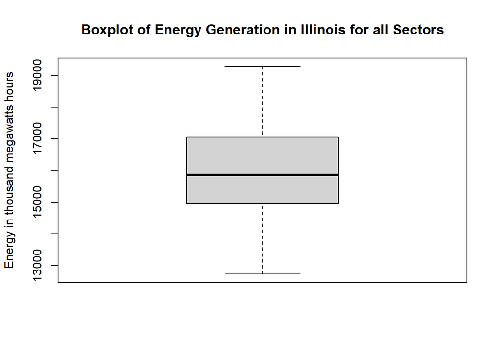

```r
# Plot a boxplot of the 'data' column
boxplot(illinois_df$Illinois...all.sectors, main = "Boxplot of Energy Generation in Illinois for all Sectors", ylab = "Energy in thousand megawatts hours")
```

The box plot indicates that the 25th percentile (Q1) value is around 15000 (thousand MWh), and the 75th percentile (Q3) value is around 17000 (thousand MWh). It also shows suggests that the distribution is slightly skewed and that there is not a lot of variability in the data points. Furthermore, there are no outliers in the dataset.

#### Convert the data into a TS object

```r
library(forecast)
library(lubridate)
#Convert the illinois data to a ts object

illinois_ts <- ts(illinois_df$Illinois...all.sectors, start =c(year(illinois_df$Date[1]), month(illinois_df$Date[1])), frequency = 12)
```

I checked for gaps in the data and there was none.

### Qualitative Analysis to Check for Stationarity

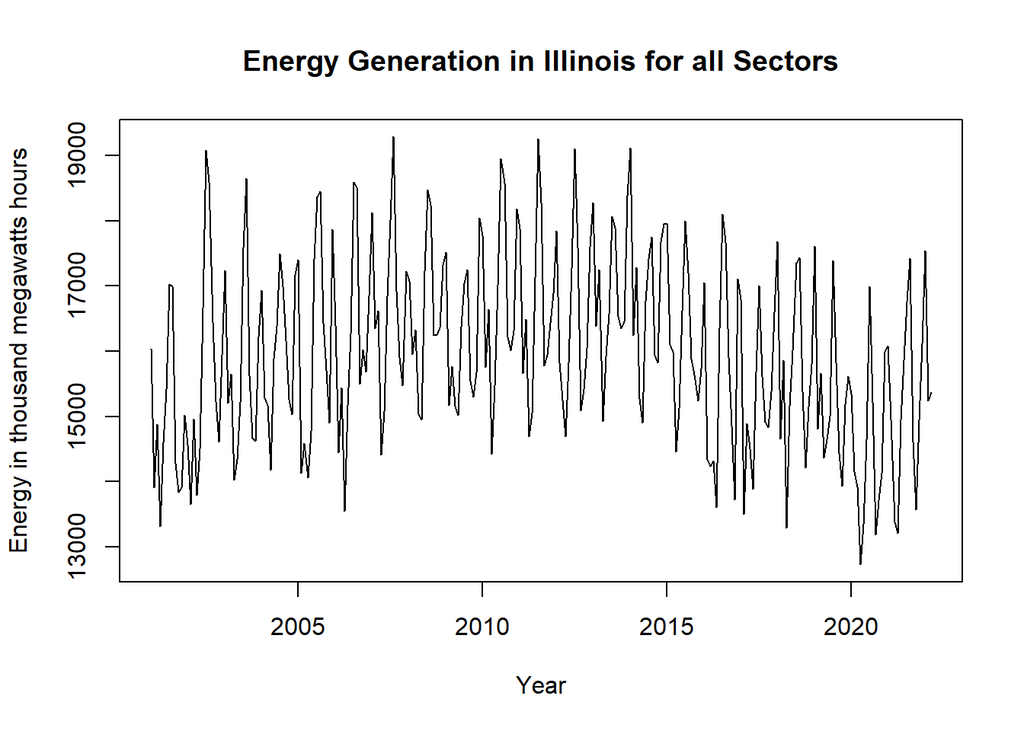

```r
# plot the xts object using plot.xts()
plot.ts(illinois_ts, main = "Energy Generation in Illinois for all Sectors",
         ylab = "Energy in thousand megawatts hours", xlab = "Year", cex.lab = 0.1)
```

The plot above shows that the time series looks non-stationary. I am not seeing any obvious trends but I suspect some seasonality.

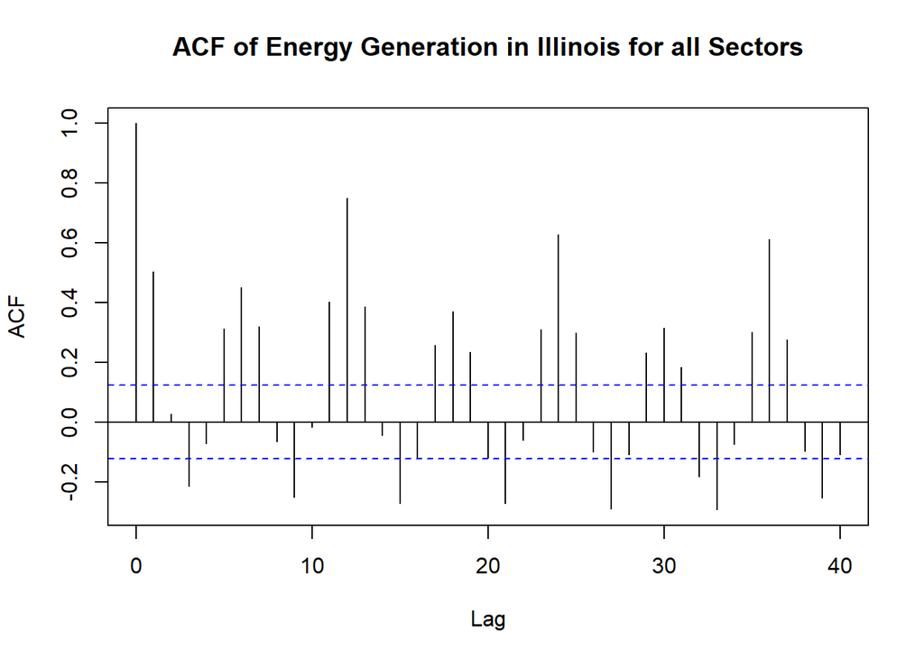

```r
# plot the ACF using acf()
acf(illinois_df$Illinois...all.sectors, main = "ACF of Energy Generation in Illinois for all Sectors", cex.main = 0.05, lag=40)
```

Since it’s a monthly data, I will use Seasonal Extraction in ARIMA Time Series (SEAT) decomposition to view the different component of the data for better clarity.

```r
library(seasonal)
```

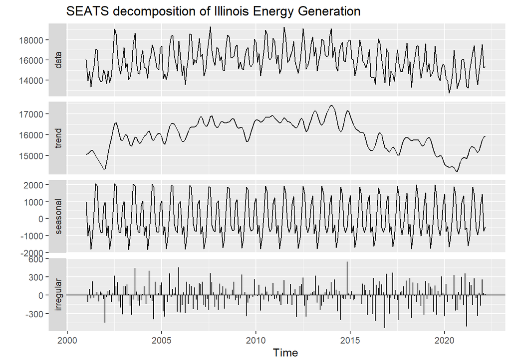

```r
illinois_ts %>% seas() %>%
autoplot() +
  ggtitle("SEATS decomposition of Illinois Energy Generation")
```

The plot above shows that the Illinois dataset has a an obvious trend and seasonality pattern. The seasonal component changes slowly over time and I notice the slight decrease in the trend from 2015. This suggest that the Illinois time series data is non-stationary. This indicates that the time series is non-stationary

### Quantitative Analysis to check for Stationarity

#### ADF Test

```r
library(tseries)
suppressWarnings(adf.test(illinois_ts))
```

```
##
##  Augmented Dickey-Fuller Test
##
## data:  illinois_ts
## Dickey-Fuller = -3.7028, Lag order = 6, p-value = 0.02435
## alternative hypothesis: stationary
```

Based on the ADF test (in which the null hypothesis is that the time series is non-stationary) the p-value of the time series is 0.02 which is less than 0.05 level of significance. This means that we reject the null hypothesis and conclude that the time series is stationary.

#### KPSS Test

```r
suppressWarnings(kpss.test(illinois_ts))
```

```
##
##  KPSS Test for Level Stationarity
##
## data:  illinois_ts
## KPSS Level = 0.80336, Truncation lag parameter = 5, p-value = 0.01
```

Based on the KPSS test (in which the null hypothesis is that the time series is stationary) the p-value of the time series is 0.01 which is less than 0.05 level of significance. This means that we will reject the null hypothesis and conclude that the time series is non-stationary.

Looking at the result of both ADF and KPSS test, the ADF test shows stationary which means that the time series basically has no unit root (indicating a trend stationary). However, the KPSS result indicate non-stationary which agrees with the qualitative analysis results. Therefore, I conclude that the Illinois time series data is non-stationary.

#### Since the Illinois time series data has mulitiple seasonality, I will try out 2 different models that I believe can handle this seasonal complexity. This woould be ARIMA with Fourier terms (used to capture seasonal patterns) and Trigonometric Box-Cox ARMA Time Series (TBATS).

#### Split data into train and test set

```r
#split my data into train and test
train_set <- subset(illinois_df, Date <= "2019-12-01")
test_set <- subset(illinois_df, Date > "2019-12-01")

# Print the number of observations in each set
cat("Number of observations in the training set:", nrow(train_set), "\n")
```

```
## Number of observations in the training set: 228
```

```r
cat("Number of observations in the test set:", nrow(test_set), "\n")
```

```
## Number of observations in the test set: 27
```

```r
#convert the train and test set to a TS object
train_ts <- ts(train_set$Illinois...all.sectors, start =c(year(train_set$Date[1]), month(train_set$Date[1])), frequency = 12)

test_ts <- ts(test_set$Illinois...all.sectors, start =c(year(test_set$Date[1]), month(train_set$Date[1])), frequency = 12)
```

### ARIMA with Fourier Terms

To determine the appropriate value of K for the Fourier terms, the highest seasonality component needs to be considered, which is the yearly seasonality (lag 12). Since the highest seasonality component is at lag 12, K can be set to half of that value or a lower value if desired. This value captures the yearly, quarterly, and semi-annual seasonality patterns in the data.

```r
library(forecast)

#Specify K
K <- 6

# Create the Fourier terms
fourier_terms <- fourier(train_ts, K = K)

# Fit the ARIMA model with Fourier terms
model_1 <- auto.arima(train_ts, xreg = fourier_terms, seasonal = FALSE)

# print the model summary
summary(model_1)
```

```
## Series: train_ts
## Regression with ARIMA(1,1,1) errors
##
## Coefficients:
##          ar1      ma1      S1-12     C1-12      S2-12     C2-12      S3-12
##       0.3659  -0.8914  -619.3461  -80.6296  1171.4216  579.4423  -199.6544
## s.e.  0.0771   0.0369    76.4615   75.9967    60.5078   60.3833    49.6100
##          C3-12     S4-12     C4-12     S5-12     C5-12      C6-12
##       349.8427  252.2845  116.0223  413.6754  -29.2568  -113.9401
## s.e.   49.6096   43.0714   43.1332   39.6451   39.7382    27.3169
##
## sigma^2 = 375464:  log likelihood = -1772.75
## AIC=3573.5   AICc=3575.48   BIC=3621.45
##
## Training set error measures:
##                    ME    RMSE      MAE         MPE     MAPE      MASE
## Training set 7.896152 593.641 474.6604 -0.07079781 2.969424 0.6841952
##                     ACF1
## Training set -0.02855344
```

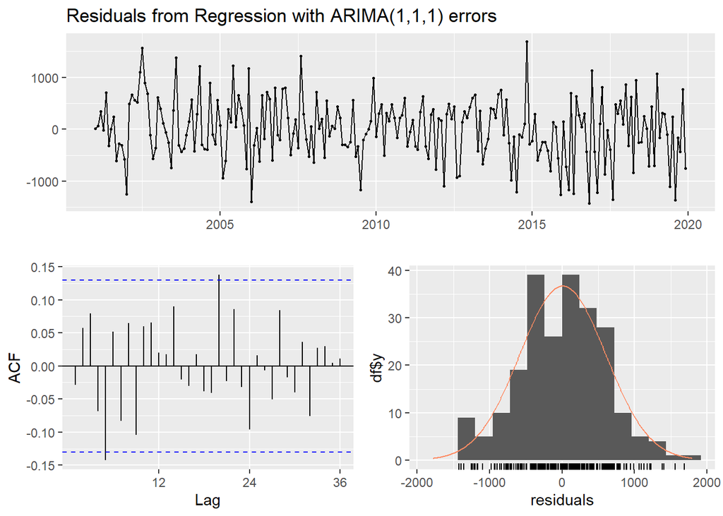

```
##
##  Ljung-Box test
##
## data:  Residuals from Regression with ARIMA(1,1,1) errors
## Q* = 28.811, df = 22, p-value = 0.1503
##
## Model df: 2.   Total lags used: 24
```

```r
#check the residuals
checkresiduals(model_1)
```

```r
#check statistics for normality test for the RIMA model with Fourier terms residuals
norm_model_1 <- shapiro.test(model_1$residuals)$p.value

norm_model_1
```

```
## [1] 0.4820205
```

I tried different values for the p and q but none had a smaller AIC values compared to the model from auto.arima. So, I will use the model from auto.arima with fourier terms for forecasting.

Based on the summary of the residual analysis plot, the ACF plot of ARIMA (1,1,1) errors with fourier terms shows that most of the spikes are within the significance limits, so the residuals appear to be white noise. The Ljung-Box test also shows a p-value of 0.1503, which is greater than 0.05 significant level. Therefore, we do not have sufficient evidence to reject the null hypothesis (that there is no autocorrelation). This suggests that there is no significant autocorrelation in the residuals of the model.

In addition, the shapiro normality test showed a p-value of 0.4820205, which is greater than the common significance level of 0.05, there is insufficient evidence to conclude that the residuals of model_1 depart significantly from a normal distribution. Therefore, we can assume that the residuals are reasonably normally distributed.

### Forecasting using ARIMA with Fourier Terms Model

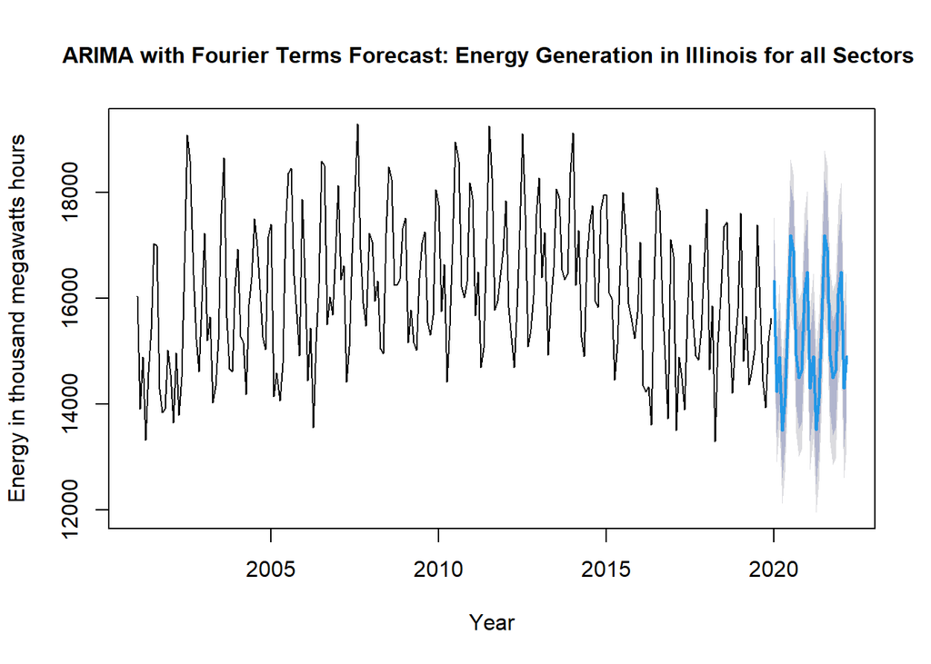

```r
# Define the forecast horizon
h <- 27  # Number of periods to forecast

# Calculate the Fourier terms for the forecast horizon
fourier_terms_forecast <- fourier(train_ts, K = K, h = h)

# Generate the forecast
illinois_forecast <- forecast(model_1, xreg = fourier_terms_forecast)


# Plot the forecasted values
plot(illinois_forecast,
     xlab = "Year",
     ylab = "Energy in thousand megawatts hours",
     main= "ARIMA with Fourier Terms Forecast: Energy Generation in Illinois for all Sectors ",
     cex.main = 1.0)
```

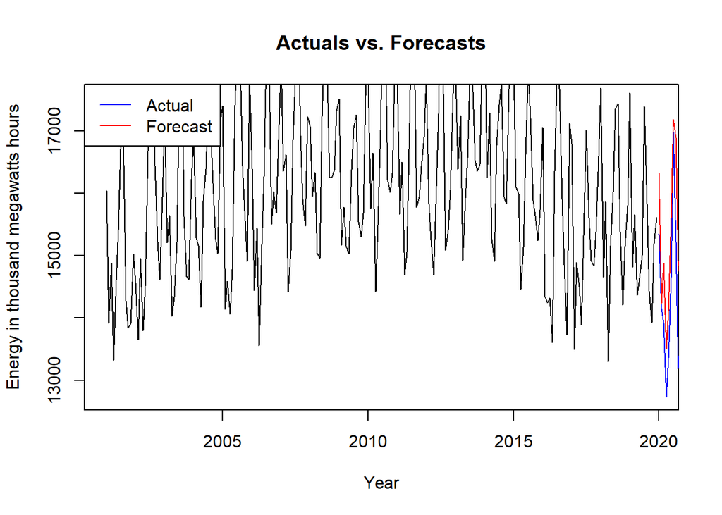

```r
# Specify the y-axis limits to provide a better view
y_min <- min(min(test_ts), min(illinois_forecast$mean)) - 10
y_max <- max(max(test_ts), max(illinois_forecast$mean)) + 10

# Plot the actual values
plot(train_ts, type = "l", xlab = "Year", ylab = "Energy in thousand megawatts hours", main = "Actuals vs. Forecasts", ylim = c(y_min, y_max))
lines(test_ts, col = "blue")  # Actual values

# Add the forecasted values to the plot
lines(illinois_forecast$mean, col = "red")  # Forecasted values

# Add a legend
legend("topleft", legend = c("Actual", "Forecast"), col = c("blue", "red"), lty = 1)
```

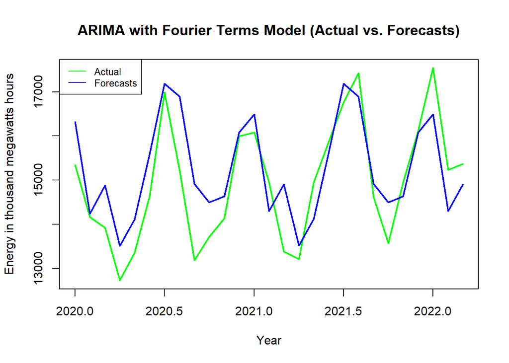

```r
# Create a new plot with the actual and forecasts

plot(test_ts, main="ARIMA with Fourier Terms Model (Actual vs. Forecasts)", xlab="Year", ylab="Energy in thousand megawatts hours", lwd=2, col="green")
lines(illinois_forecast$mean, col="blue", lwd=2)

# Add a legend
legend("topleft", legend=c("Actual", "Forecasts"), col=c("green", "blue"), lty=1, cex=0.8)
```

```r
# Calculate the MSE for the ARIMA with Fourier terms model
MSE_arima_fourier <- mean((test_set$Illinois...all.sectors - illinois_forecast$mean)^2)


#print the summary
print(MSE_arima_fourier)
```

```
## [1] 673589
```

An MSE of 673,589 suggests that, on average, the squared difference between the forecasted values and the actual values is approximately 673,589 thousand megawatt-hours squared.

```r
#write a function to calculate the sMAPE
calculate_smape <- function(actual, predicted) {
  absolute_difference <- abs(actual - predicted)
  absolute_sum <- abs(actual) + abs(predicted)
  smape <- (2 * absolute_difference / absolute_sum) * 100
  mean_smape <- mean(smape, na.rm = TRUE)
  return(mean_smape)
}


#get the mean SMAPE score for model 1
smape_score_model1 <- calculate_smape(test_set$Illinois...all.sectors, illinois_forecast$mean)
print(paste("Model1 SMAPE:", smape_score_model1))
```

```
## [1] "Model1 SMAPE: 4.60110911034304"
```

Based on the mean SMAPE analysis of the ARIMA with fourier terms model,it has the mean SMAPE of 4.6. This indicate that it has an average percentage error of 4.6 between the predicted values and the actual values.

```r
illinois_forecast
```

```
##          Point Forecast    Lo 80    Hi 80    Lo 95    Hi 95
## Jan 2020       16322.92 15537.65 17108.20 15121.95 17523.89
## Feb 2020       14235.15 13365.97 15104.33 12905.85 15564.45
## Mar 2020       14884.60 13987.62 15781.59 13512.78 16256.42
## Apr 2020       13507.18 12594.90 14419.46 12111.97 14902.39
## May 2020       14114.71 13190.80 15038.62 12701.71 15527.70
## Jun 2020       15603.54 14669.27 16537.81 14174.70 17032.38
## Jul 2020       17188.28 16244.17 18132.40 15744.38 18632.19
## Aug 2020       16896.68 15942.95 17850.41 15438.08 18355.28
## Sep 2020       14919.58 13956.39 15882.77 13446.51 16392.65
## Oct 2020       14495.25 13522.71 15467.79 13007.88 15982.62
## Nov 2020       14633.78 13651.98 15615.57 13132.25 16135.31
## Dec 2020       16084.58 15093.61 17075.54 14569.03 17600.13
## Jan 2021       16494.74 15494.69 17494.78 14965.30 18024.18
## Feb 2021       14298.02 13288.97 15307.06 12754.81 15841.22
## Mar 2021       14907.60 13889.64 15925.57 13350.76 16464.45
## Apr 2021       13515.60 12488.78 14542.41 11945.22 15085.97
## May 2021       14117.79 13082.21 15153.36 12534.01 15701.57
## Jun 2021       15604.67 14560.40 16648.94 14007.59 17201.75
## Jul 2021       17188.70 16135.80 18241.59 15578.43 18798.96
## Aug 2021       16896.83 15835.39 17958.28 15273.49 18520.17
## Sep 2021       14919.64 13849.71 15989.57 13283.32 16555.95
## Oct 2021       14495.27 13416.92 15573.62 12846.08 16144.46
## Nov 2021       14633.78 13547.09 15720.48 12971.82 16295.75
## Dec 2021       16084.58 14989.59 17179.57 14409.94 17759.22
## Jan 2022       16494.74 15391.52 17597.95 14807.52 18181.95
## Feb 2022       14298.02 13186.64 15409.39 12598.31 15997.72
## Mar 2022       14907.60 13788.12 16027.09 13195.50 16619.71
```

### Trigonometric Box-Cox ARMA Time Series (TBATS)

```r
library(forecast)

#fit the TBATS model to the train set
tbats_model <- tbats(train_ts)

#print the summary of the tbats model
summary(tbats_model)
```

[output not shown]

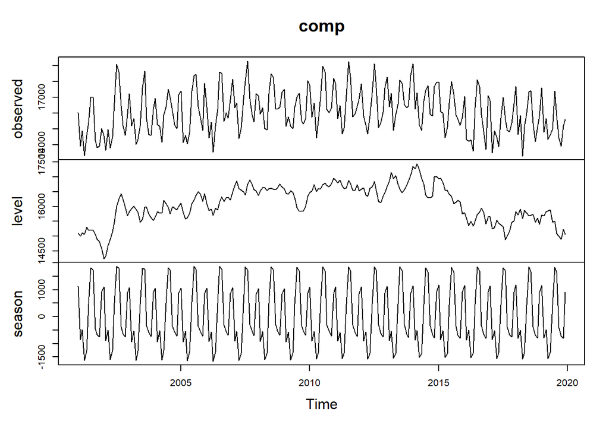

```r
#extract the TBATS components of the model
comp <- tbats.components(tbats_model)

#plot the TBATS component
plot(comp)
```

```r
#get the AIC value of the tbats model
tbats_model$AIC
```

```
## [1] 4201.844
```

TBATS Residual Analysis

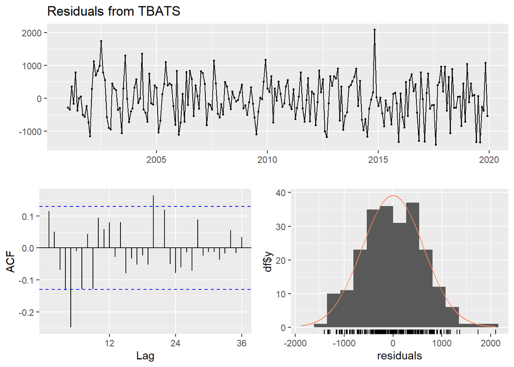

```
##
##  Ljung-Box test
##
## data:  Residuals from TBATS
## Q* = 54.112, df = 24, p-value = 0.0004119
##
## Model df: 0.   Total lags used: 24
```

```r
#check for residuals
checkresiduals(tbats_model)
```

```r
#check statistics for normality test for the RIMA model with Fourier terms residuals
norm_tbats <- shapiro.test(tbats_model$errors)$p.value

norm_tbats
```

```
## [1] 0.4596458
```

However, the shapiro normality test showed a p-value of 0.4596458, which is greater than the common significance level of 0.05, there is insufficient evidence to conclude that the residuals of model_1 depart significantly from a normal distribution. Therefore, we can assume that the residuals are reasonably normally distributed.

### Forecasting using TBATS

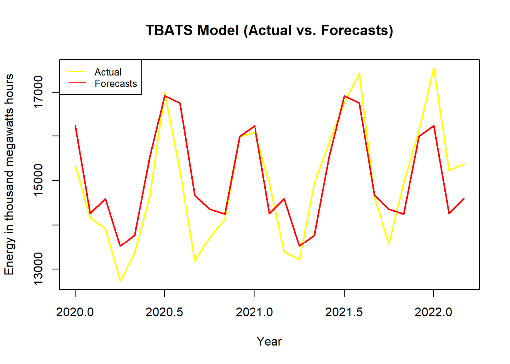

```r
#forecast using the tbats model
forecast_tbats <- forecast(tbats_model, h = length(test_ts))


# Create a new plot with the actual and forecasts

plot(test_ts, main="TBATS Model (Actual vs. Forecasts)", xlab="Year", ylab="Energy in thousand megawatts hours", lwd=2, col="yellow")
lines(forecast_tbats$mean, col="red", lwd=2)

# Add a legend
legend("topleft", legend=c("Actual", "Forecasts"), col=c("yellow", "red"), lty=1, cex=0.8)
```

```r
# Calculate the MSE for the tbats model
MSE_tbats <- mean((test_set$Illinois...all.sectors - forecast_tbats$mean)^2)


#print the summary
print(MSE_tbats)
```

```
## [1] 601893.2
```

An MSE of 601,893 suggests that, on average, the squared difference between the forecasted values and the actual values is approximately 601,893 thousand megawatt-hours squared.

```r
#get the mean SMAPE score for model 1
smape_score_tbats <- calculate_smape(test_set$Illinois...all.sectors, forecast_tbats$mean)

print(paste("Tbats SMAPE:", smape_score_tbats))
```

```
## [1] "Tbats SMAPE: 4.25558740264263"
```